# Analisi delle armi di DarkSouls3

by Marco Venir

# Premesse

Dark Souls 3 é un RPG in cui il giocatore accumula oggetti e migliora le proprie statistiche per sconfiggere dei nemici.

Questa analisi si focalizza sulle armi.

# Personaggio

https://darksouls3-italia.wiki.fextralife.com/Statistiche

Ogni personaggio possiede 9 attributi:

Vitalità, Armonizzazione, Tempra, Vigore, **Forza**, **Destrezza**, **Intelligenza**, **Fede**, **Fortuna**

Di queste ci interessano in particolare quelle in grassetto, che servono a calcolare determinati tipi di danno che le armi possono causare.

# Armi

https://darksouls3-italia.wiki.fextralife.com/Armi

Ogni arma possiede 5 parametri danno base: fisico, magico, fuoco, elettrico, oscuro.

Questi 5 parametri poi possono aumentare in base al livello di **Scaling** dell'arma e al livello degli attributi del personaggio.

**Scaling** : un'arma puó aumentare determinati tipi di danno in base al livello di scaling per quel danno e al livello dell'attributo corrispondente.

Le armi possono essere infuse con delle gemme, ció consente di aggiungere dei danni di base o di incrementare quelli giá presenti.

[figure not shown]

# Domande di partenza

1. Quali sono le armi piú forti del gioco? Come dipendono dalle statistiche del personaggio?
2. Quanto é importante assegnare correttamente le statistiche? Quanto danno si perde assegnandole casualmente?
3. Che tipo di infusioni rendono le armi piú potenti?
4. Ci sono armi che rimangono valide indipendentemente dal tipo di infusione?

# Illustrazione dei DataSet

https://blog.mugenmonkey.com/2016/07/22/how-to-calculate-ar.html https://docs.google.com/spreadsheets/d/1nGXbJ5DEaWCtXHhj46Wws4HM0KkV85nyczJemqmtDF8/edit?gid=0#gid=0

|  | Weapon Name | Weapon Type | Str (SC) | Dex (SC) | Int (SC) | Faith (SC) | Luck (SC) | Physical (BD) | Magic (BD) | Fire (BD) | Lightning (BD) | Dark (BD) | Physical (SCI) | Magic (SCI) | Fire (SCI) | Lightning (SCI) | Dark (SCI) |
| --- | --- | --- | --- | --- | --- | --- | --- | --- | --- | --- | --- | --- | --- | --- | --- | --- | --- |
| 0 | Dagger | Dagger | 14.000000 | 98.000000 | 0.000000 | 0.000000 | 0.000000 | 116.000000 | 0.000000 | 0.000000 | 0.000000 | 0.000000 | 9 | 0 | 0 | 0 | 0 |
| 1 | Heavy Dagger | Dagger | 100.800000 | 0.000000 | 0.000000 | 0.000000 | 0.000000 | 107.300000 | 0.000000 | 0.000000 | 0.000000 | 0.000000 | 9 | 0 | 0 | 0 | 0 |
| 2 | Sharp Dagger | Dagger | 5.500000 | 147.000000 | 0.000000 | 0.000000 | 0.000000 | 107.300000 | 0.000000 | 0.000000 | 0.000000 | 0.000000 | 9 | 0 | 0 | 0 | 0 |
| 3 | Refined Dagger | Dagger | 84.800000 | 84.800000 | 0.000000 | 0.000000 | 0.000000 | 104.400000 | 0.000000 | 0.000000 | 0.000000 | 0.000000 | 8 | 0 | 0 | 0 | 0 |
| 4 | Simple Dagger | Dagger | 13.000000 | 91.000000 | 112.000000 | 0.000000 | 0.000000 | 63.000000 | 72.450000 | 0.000000 | 0.000000 | 0.000000 | 0 | 0 | 0 | 0 | 0 |
| 5 | Crystal Dagger | Dagger | 10.000000 | 70.000000 | 132.000000 | 0.000000 | 0.000000 | 59.850000 | 81.900000 | 0.000000 | 0.000000 | 0.000000 | 0 | 0 | 0 | 0 | 0 |
| 6 | Fire Dagger | Dagger | 0.000000 | 0.000000 | 0.000000 | 0.000000 | 0.000000 | 120.450000 | 0.000000 | 120.450000 | 0.000000 | 0.000000 | 0 | 0 | 0 | 0 | 0 |
| 7 | Chaos Dagger | Dagger | 12.000000 | 84.000000 | 88.000000 | 88.000000 | 0.000000 | 63.000000 | 0.000000 | 81.900000 | 0.000000 | 0.000000 | 0 | 0 | 0 | 0 | 0 |
| 8 | Lightning Dagger | Dagger | 10.000000 | 70.000000 | 0.000000 | 132.000000 | 0.000000 | 59.850000 | 0.000000 | 0.000000 | 81.900000 | 0.000000 | 0 | 0 | 0 | 0 | 0 |
| 9 | Deep Dagger | Dagger | 0.000000 | 0.000000 | 0.000000 | 0.000000 | 0.000000 | 120.450000 | 0.000000 | 0.000000 | 0.000000 | 120.450000 | 0 | 0 | 0 | 0 | 0 |
| 10 | Dark Dagger | Dagger | 12.000000 | 84.000000 | 88.000000 | 88.000000 | 0.000000 | 63.000000 | 0.000000 | 0.000000 | 0.000000 | 81.900000 | 0 | 0 | 0 | 0 | 0 |
| 11 | Poison Dagger | Dagger | 14.000000 | 98.000000 | 0.000000 | 0.000000 | 0.000000 | 89.900000 | 0.000000 | 0.000000 | 0.000000 | 0.000000 | 9 | 0 | 0 | 0 | 0 |
| 12 | Blood Dagger | Dagger | 14.000000 | 98.000000 | 0.000000 | 0.000000 | 0.000000 | 89.900000 | 0.000000 | 0.000000 | 0.000000 | 0.000000 | 9 | 0 | 0 | 0 | 0 |
| 13 | Raw Dagger | Dagger | 0.000000 | 0.000000 | 0.000000 | 0.000000 | 0.000000 | 145.000000 | 0.000000 | 0.000000 | 0.000000 | 0.000000 | 9 | 0 | 0 | 0 | 0 |
| 14 | Blessed Dagger | Dagger | 11.000000 | 77.000000 | 0.000000 | 104.000000 | 0.000000 | 81.900000 | 0.000000 | 0.000000 | 0.000000 | 0.000000 | 9 | 0 | 0 | 0 | 0 |
| 15 | Hollow Dagger | Dagger | 14.000000 | 98.000000 | 0.000000 | 0.000000 | 36.000000 | 110.200000 | 0.000000 | 0.000000 | 0.000000 | 0.000000 | 9 | 0 | 0 | 0 | 0 |
| 16 | Bandit's Knife | Dagger | 35.000000 | 42.000000 | 0.000000 | 0.000000 | 0.000000 | 140.000000 | 0.000000 | 0.000000 | 0.000000 | 0.000000 | 9 | 0 | 0 | 0 | 0 |
| 17 | Heavy Bandit's Knife | Dagger | 69.300000 | 0.000000 | 0.000000 | 0.000000 | 0.000000 | 129.500000 | 0.000000 | 0.000000 | 0.000000 | 0.000000 | 9 | 0 | 0 | 0 | 0 |
| 18 | Sharp Bandit's Knife | Dagger | 13.200000 | 63.000000 | 0.000000 | 0.000000 | 0.000000 | 129.500000 | 0.000000 | 0.000000 | 0.000000 | 0.000000 | 9 | 0 | 0 | 0 | 0 |
| 19 | Refined Bandit's Knife | Dagger | 59.200000 | 59.200000 | 0.000000 | 0.000000 | 0.000000 | 126.000000 | 0.000000 | 0.000000 | 0.000000 | 0.000000 | 8 | 0 | 0 | 0 | 0 |
| 20 | Simple Bandit's Knife | Dagger | 32.500000 | 39.000000 | 77.000000 | 0.000000 | 0.000000 | 75.000000 | 86.250000 | 0.000000 | 0.000000 | 0.000000 | 0 | 0 | 0 | 0 | 0 |
| 21 | Crystal Bandit's Knife | Dagger | 25.000000 | 30.000000 | 90.750000 | 0.000000 | 0.000000 | 71.250000 | 97.500000 | 0.000000 | 0.000000 | 0.000000 | 0 | 0 | 0 | 0 | 0 |
| 22 | Fire Bandit's Knife | Dagger | 0.000000 | 0.000000 | 0.000000 | 0.000000 | 0.000000 | 127.050000 | 0.000000 | 127.050000 | 0.000000 | 0.000000 | 0 | 0 | 0 | 0 | 0 |
| 23 | Chaos Bandit's Knife | Dagger | 30.000000 | 36.000000 | 60.500000 | 60.500000 | 0.000000 | 75.000000 | 0.000000 | 97.500000 | 0.000000 | 0.000000 | 0 | 0 | 0 | 0 | 0 |
| 24 | Lightning Bandit's Knife | Dagger | 25.000000 | 30.000000 | 0.000000 | 90.750000 | 0.000000 | 71.250000 | 0.000000 | 0.000000 | 97.500000 | 0.000000 | 0 | 0 | 0 | 0 | 0 |
| 25 | Deep Bandit's Knife | Dagger | 0.000000 | 0.000000 | 0.000000 | 0.000000 | 0.000000 | 127.050000 | 0.000000 | 0.000000 | 0.000000 | 127.050000 | 0 | 0 | 0 | 0 | 0 |
| 26 | Dark Bandit's Knife | Dagger | 30.000000 | 36.000000 | 60.500000 | 60.500000 | 0.000000 | 75.000000 | 0.000000 | 0.000000 | 0.000000 | 97.500000 | 0 | 0 | 0 | 0 | 0 |
| 27 | Poison Bandit's Knife | Dagger | 35.000000 | 42.000000 | 0.000000 | 0.000000 | 0.000000 | 108.500000 | 0.000000 | 0.000000 | 0.000000 | 0.000000 | 9 | 0 | 0 | 0 | 0 |
| 28 | Blood Bandit's Knife | Dagger | 35.000000 | 42.000000 | 0.000000 | 0.000000 | 0.000000 | 108.500000 | 0.000000 | 0.000000 | 0.000000 | 0.000000 | 9 | 0 | 0 | 0 | 0 |
| 29 | Raw Bandit's Knife | Dagger | 0.000000 | 0.000000 | 0.000000 | 0.000000 | 0.000000 | 175.000000 | 0.000000 | 0.000000 | 0.000000 | 0.000000 | 9 | 0 | 0 | 0 | 0 |

[output cut: 2169 more lines]

|  | Curve Index | Level 0 | Level 1 | Level 2 | Level 3 | Level 4 | Level 5 | Level 6 | Level 7 | Level 8 | Level 9 | Level 10 | Level 11 | Level 12 | Level 13 | Level 14 | Level 15 | Level 16 | Level 17 | Level 18 | Level 19 | Level 20 | Level 21 | Level 22 | Level 23 | Level 24 | Level 25 | Level 26 | Level 27 | … |
| --- | --- | --- | --- | --- | --- | --- | --- | --- | --- | --- | --- | --- | --- | --- | --- | --- | --- | --- | --- | --- | --- | --- | --- | --- | --- | --- | --- | --- | --- | --- |
| 0 | 0 | 0 | 0 | 0.834452 | 1.917067 | 3.118508 | 4.404263 | 5.756590 | 7.164449 | 8.620232 | 10.118340 | 11.654464 | 13.225171 | 14.827657 | 16.459582 | 18.118962 | 19.804092 | 21.513487 | 23.245842 | 25.000000 | 27.714723 | 30.403705 | 33.065921 | 35.700249 | 38.305456 | 40.880177 | 43.422896 | 45.931914 | 48.405317 | … |
| 1 | 1 | 0 | 0 | 1.357558 | 3.118850 | 5.073458 | 7.165236 | 9.365318 | 11.655745 | 14.024138 | 16.461391 | 18.960489 | 21.515851 | 24.122913 | 26.777870 | 29.477494 | 32.219009 | 35.000000 | 36.991572 | 38.965897 | 40.922349 | 42.860250 | 44.778861 | 46.677375 | 48.554900 | 50.410456 | 52.242947 | 54.051152 | 55.833689 | … |
| 2 | 2 | 0 | 0 | 1.163622 | 2.673300 | 4.348678 | 6.141631 | 8.027416 | 9.990638 | 12.020690 | 14.109763 | 16.251848 | 18.442158 | 20.676783 | 22.952460 | 25.266423 | 27.616293 | 30.000000 | 32.240519 | 34.461634 | 36.662642 | 38.842781 | 41.001219 | 43.137046 | 45.249263 | 47.336763 | 49.398316 | 51.432546 | 53.437900 | … |
| 3 | 5 | 0 | 0 | 0.965517 | 1.931034 | 2.896552 | 3.862069 | 4.827586 | 5.793103 | 6.758621 | 7.724138 | 8.689655 | 9.655172 | 10.620690 | 11.586207 | 12.551724 | 13.517241 | 14.482759 | 15.448276 | 16.413793 | 17.379310 | 18.344828 | 19.310345 | 20.275862 | 21.241379 | 22.206897 | 23.172414 | 24.137931 | 25.103448 | … |
| 4 | 6 | 0 | 0 | 0.416667 | 0.833333 | 1.250000 | 1.666667 | 2.083333 | 2.500000 | 2.916667 | 3.333333 | 3.750000 | 4.166667 | 4.583333 | 5.000000 | 5.416667 | 5.833333 | 6.250000 | 6.666667 | 7.083333 | 7.500000 | 7.916667 | 8.333333 | 8.750000 | 9.166667 | 9.583333 | 10.000000 | 12.250000 | 14.500000 | … |
| 5 | 8 | 0 | 0 | 0.969685 | 2.227750 | 3.623898 | 5.118026 | 6.689513 | 8.325532 | 10.017242 | 11.758136 | 13.543207 | 15.368465 | 17.230652 | 19.127050 | 21.055353 | 23.013578 | 25.000000 | 27.240519 | 29.461634 | 31.662642 | 33.842781 | 36.001219 | 38.137046 | 40.249263 | 42.336763 | 44.398316 | 46.432546 | 48.437900 | … |
| 6 | 9 | 0 | 25 | 26.431987 | 28.289842 | 30.351610 | 32.558071 | 34.878773 | 37.294772 | 39.793013 | 42.363888 | 45.000000 | 46.195964 | 47.383707 | 48.562994 | 49.733577 | 50.895187 | 52.047540 | 53.190327 | 54.323217 | 55.445852 | 56.557842 | 57.658763 | 58.748152 | 59.825498 | 60.890237 | 61.941742 | 62.979310 | 64.002151 | … |
| 7 | 12 | 0 | 0 | 0.714286 | 1.428571 | 2.142857 | 2.857143 | 3.571429 | 4.285714 | 5.000000 | 5.714286 | 6.428571 | 7.142857 | 7.857143 | 8.571429 | 9.285714 | 10.000000 | 13.000000 | 16.000000 | 19.000000 | 22.000000 | 25.000000 | 28.000000 | 31.000000 | 34.000000 | 37.000000 | 40.000000 | 43.000000 | 46.000000 | … |
| 8 | 14 | 0 | 0 | 0.714286 | 1.428571 | 2.142857 | 2.857143 | 3.571429 | 4.285714 | 5.000000 | 5.714286 | 6.428571 | 7.142857 | 7.857143 | 8.571429 | 9.285714 | 10.000000 | 13.000000 | 16.000000 | 19.000000 | 22.000000 | 25.000000 | 28.000000 | 31.000000 | 34.000000 | 37.000000 | 40.000000 | 43.000000 | 46.000000 | … |
| 9 | 15 | 0 | 0 | 1.785714 | 3.571429 | 5.357143 | 7.142857 | 8.928571 | 10.714286 | 12.500000 | 14.285714 | 16.071429 | 17.857143 | 19.642857 | 21.428571 | 23.214286 | 25.000000 | 28.333333 | 31.666667 | 35.000000 | 38.333333 | 41.666667 | 45.000000 | 48.333333 | 51.666667 | 55.000000 | 58.333333 | 61.666667 | 65.000000 | … |
| 10 | 16 | 0 | 0 | 0.000000 | 0.000000 | 0.000000 | 0.000000 | 0.000000 | 0.000000 | 0.000000 | 0.000000 | 0.000000 | 0.000000 | 0.000000 | 0.000000 | 0.000000 | 0.000000 | 0.000000 | 0.000000 | 0.000000 | 2.407407 | 4.814815 | 7.222222 | 9.629630 | 12.037037 | 14.444444 | 16.851852 | 19.259259 | 21.666667 | … |

# Categorie di personaggio

All'interno del gioco la distribuzione delle statistiche con l'aumento del livello dipende dalle scelte del giocatore. In questa analisi confronteremo 2 tipi di build:

1. Il personaggio ottimale : statistiche assegnate nel miglior modo possibile.
2. Il personaggio casuale : statistiche assegnate casualmente

Per i confronti sulla stessa arma useremo delle build con ugual numero di livelli.

|  | Categoria | Str | Dex | Int | Faith | Luck |
| --- | --- | --- | --- | --- | --- | --- |
| 0 | Standard | 100 | 0 | 0 | 0 | 0 |
| 1 | Standard | 0 | 100 | 0 | 0 | 0 |
| 2 | Standard | 0 | 0 | 100 | 0 | 0 |
| 3 | Standard | 0 | 0 | 0 | 100 | 0 |
| 4 | Standard | 0 | 0 | 0 | 0 | 100 |
| 5 | Standard | 100 | 100 | 0 | 0 | 0 |
| 6 | Standard | 100 | 0 | 100 | 0 | 0 |
| 7 | Standard | 100 | 0 | 0 | 100 | 0 |
| 8 | Standard | 100 | 0 | 0 | 0 | 100 |
| 9 | Standard | 0 | 100 | 100 | 0 | 0 |
| 10 | Standard | 0 | 100 | 0 | 100 | 0 |
| 11 | Standard | 0 | 100 | 0 | 0 | 100 |
| 12 | Standard | 0 | 0 | 100 | 100 | 0 |
| 13 | Standard | 0 | 0 | 100 | 0 | 100 |
| 14 | Standard | 0 | 0 | 0 | 100 | 100 |
| 15 | Standard | 100 | 100 | 100 | 0 | 0 |
| 16 | Standard | 100 | 100 | 0 | 100 | 0 |
| 17 | Standard | 100 | 100 | 0 | 0 | 100 |
| 18 | Standard | 100 | 0 | 100 | 100 | 0 |
| 19 | Standard | 100 | 0 | 100 | 0 | 100 |
| 20 | Standard | 100 | 0 | 0 | 100 | 100 |
| 21 | Standard | 0 | 100 | 100 | 100 | 0 |
| 22 | Standard | 0 | 100 | 100 | 0 | 100 |
| 23 | Standard | 0 | 100 | 0 | 100 | 100 |
| 24 | Standard | 0 | 0 | 100 | 100 | 100 |
| 25 | Standard | 100 | 100 | 100 | 100 | 0 |
| 26 | Standard | 100 | 100 | 100 | 0 | 100 |
| 27 | Standard | 100 | 100 | 0 | 100 | 100 |
| 28 | Standard | 100 | 0 | 100 | 100 | 100 |
| 29 | Standard | 0 | 100 | 100 | 100 | 100 |

[output cut: 497 more lines]

# Formula per calcolare il danno Totale delle armi

AR = Base Physical + Base Magic + Base Fire + Base Lightning + Base Dark + Base Physical * (Strength Scaling Coefficient * Physical Saturation + Dex Scaling Coefficient * Physical Saturation + Luck Scaling Coefficient * Physical Saturation + Faith Scaling Coefficient * Physical Saturation) + Base Magic * (Intelligence Scaling Coefficient * Magic Saturation) + Base Fire * (Intelligence Scaling Coefficient * Fire Saturation + Faith Scaling Coefficient * Fire Saturation) + Base Lightning * (Faith Scaling Coefficient * Lightning Saturation) + Base Dark * (Intelligence Scaling Coefficient * Dark Saturation + Faith Scaling Coefficient * Dark Saturation)

# Calcolo del danno massimo per ogni arma

1. **Build Ottimale** : identifico i tipi di danno per cui l'arma ha un livello di scaling diverso da 0 e associo all'arma la build piú adatta estraendola da quelle generate precedentemente.
2. **Build Casuale** : estraggo casualmente una build random da quelle generate che abbia il totale di livelli corrispondente alla build ottimale scelta.

Dopo aver scelto le build con le statistiche procedo al calcolo del danno massimo.

## 1. Quali sono le armi piú forti del gioco? Come dipendono dalle statistiche del personaggio?

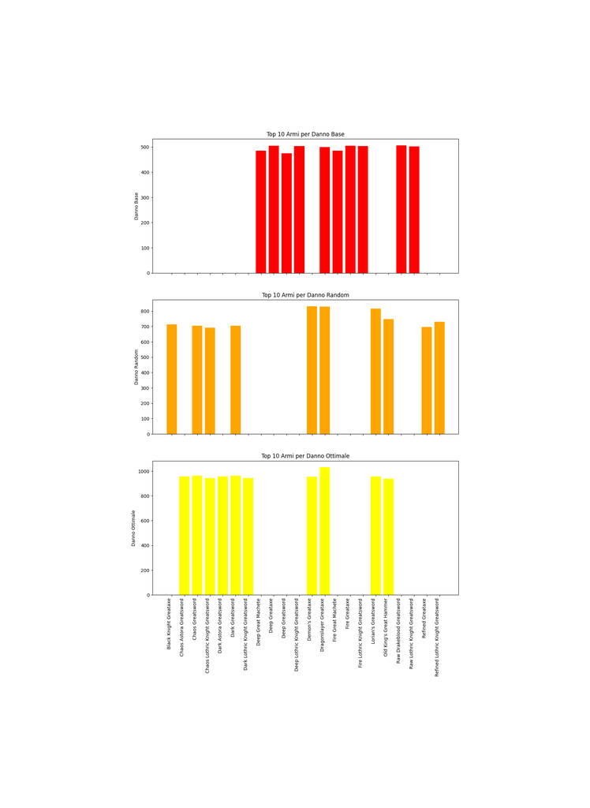

## Risposta

Tra tutte le armi ne sono state scelte 22, ognuna delle quali rientra nelle prime 10 in almeno una categoria di danno. La Dragonslayer GreatAxe é la piú forte arma con build ottimale ed é presente in tutti e 3 i grafici, dimostrando di essere molto forte in ogni contesto.

## 2. Quanto é importante assegnare correttamente le statistiche? Quanto danno si perde assegnandole casualmente?

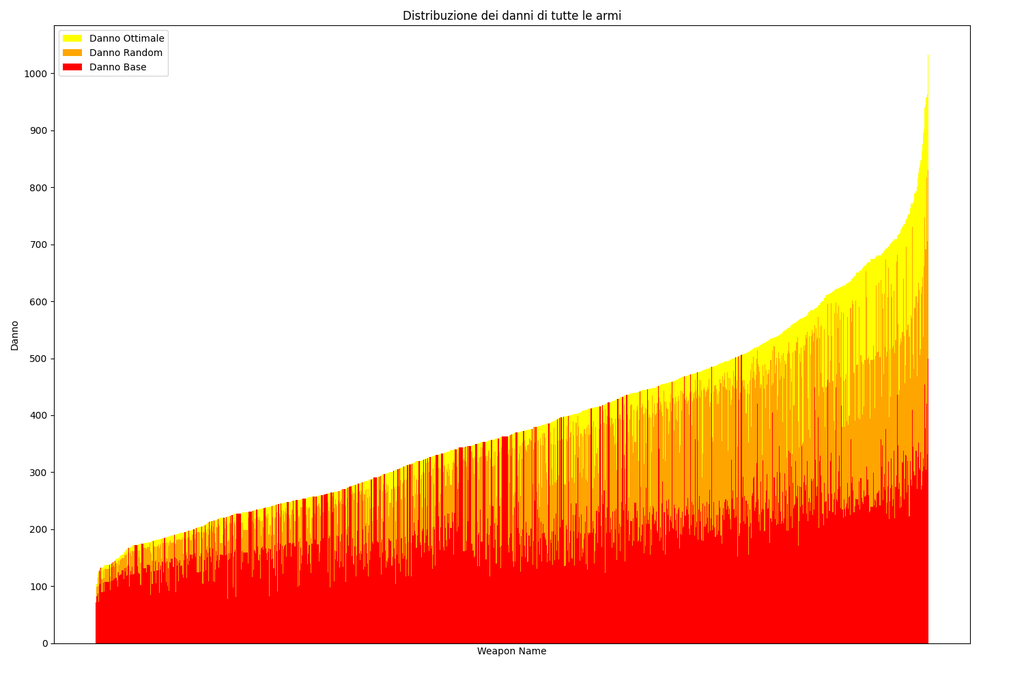

## Risposta

Vediamo il confronto tra 2 modi di assegnare le statistiche. La differenza maggiore riguarda le armi piú forti, che si presume siano acquisite verso la fine del gioco quando il giocatore ha accumulato molti livelli.

In generale la differenza non é altissima e quindi non stravolge le meccaniche di gioco (perdo in media l'11% dei danni).

Notiamo anche come alcune armi abbiano il tetto massimo come danno di base, queste sono le armi che non hanno fattori di scaling e quindi la cui potenza é indipendente dalle statistiche assegnate.

# Infusioni

Le infusioni possono essere dei seguenti tipi: Normal, Heavy, Sharp, Refined, Simple, Crystal, Fire, Chaos, Lightning, Deep, Dark, Poison, Blood, Raw, Blessed, Hollow

Ogni infusione scala in base a determinati parametri e statistiche, quindi a paritá di statistiche ci si aspetta di ottenere danni diversi con infusioni diverse.

## 3. Che tipo di infusioni rendono le armi piú potenti?

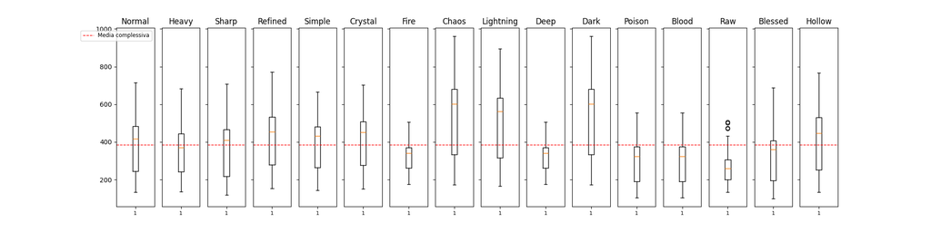

## Risposta

Per ogni arma vengono confrontati tutti i tipi di danno corrispondenti alle varie infusioni. Prevalgono nettamente le infusioni: Chaos, Dark, Lightning. Invece peggiorano le armi le infusioni: Fire, Deep, Poison, Blood e Raw.

Spiccano 2 valori outlayer nel grafico relativo all'infusione Raw: la DrakeBlood GreatSword e Lothric Knight GreatSword.

|  | Weapon Name | Weapon Type | Str (SC) | Dex (SC) | Int (SC) | Faith (SC) | Luck (SC) | Physical (BD) | Magic (BD) | Fire (BD) | Lightning (BD) | Dark (BD) | Physical (SCI) | Magic (SCI) | Fire (SCI) | Lightning (SCI) | Dark (SCI) |
| --- | --- | --- | --- | --- | --- | --- | --- | --- | --- | --- | --- | --- | --- | --- | --- | --- | --- |
| 561 | Lothric Knight Greatsword | Ultra Greatsword | 43.400000 | 63.000000 | 0.000000 | 0.000000 | 0.000000 | 262.000000 | 0.000000 | 0.000000 | 174.000000 | 0.000000 | 0 | 0 | 0 | 0 | 0 |
| 574 | Raw Lothric Knight Greatsword | Ultra Greatsword | 0.000000 | 0.000000 | 0.000000 | 0.000000 | 0.000000 | 327.500000 | 0.000000 | 0.000000 | 174.000000 | 0.000000 | 0 | 0 | 0 | 0 | 0 |
| 654 | Drakeblood Greatsword | Greatsword | 42.000000 | 42.000000 | 0.000000 | 0.000000 | 0.000000 | 178.000000 | 142.000000 | 0.000000 | 142.000000 | 0.000000 | 0 | 0 | 0 | 0 | 0 |
| 667 | Raw Drakeblood Greatsword | Greatsword | 0.000000 | 0.000000 | 0.000000 | 0.000000 | 0.000000 | 222.500000 | 142.000000 | 0.000000 | 142.000000 | 0.000000 | 0 | 0 | 0 | 0 | 0 |

## 4. Ci sono armi che rimangono valide (o non valide) indipendentemente dal tipo di infusione?

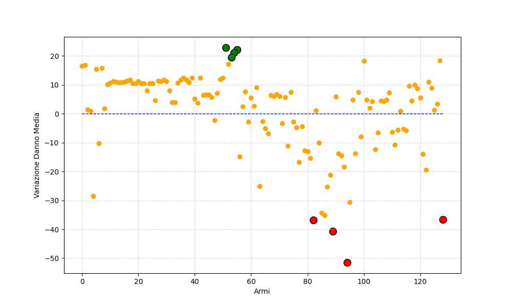

## Risposta

# Conclusioni

Assegnare correttamente le statistiche e saper infondere le proprie armi é utile per:

1. Massimizzare il danno delle armi.
2. Evitare di compromettere armi buone rendendole inutilizzabili.

Tuttavia la maggior parte delle armi rimane utilizzabile anche senza saperne sfruttare le caratteristiche, il che rende possibile un gameplay anche per i meno esperti.

Per quanto riguarda le infusioni, è essenziale fare scelte consapevoli. Come mostra il grafico, nelle fasi avanzate del gioco c’è il rischio che il danno delle armi diminuisca sensibilmente, quindi è fondamentale selezionare le infusioni corrette.